# Week 4 HW

Tyler Jackson

4/22/2019

# Week 4, Part 1 (Lab 7)

## Libraries

```r
library(raster)
library(rgdal)
library(MASS)
library(tidyverse)
library(rasterVis)
```

## Setup

```r
#data path
mypath <- "/Users/tyler/Dropbox/_200CN/labs/week4/data/"

#unzip lab7 data
unzip(zipfile = file.path(mypath, "lab7_data.zip"), exdir = file.path(mypath))
```

# Part 1

**Logistic regression**

## 1 Fix non-logical variable

The following code returns an error:

```r
#create Yes/No variable for travels by train
y <- c('No','Yes','No','Yes','No','Yes',
       'No','Yes','Yes','Yes','No','No',
       'No','No','Yes','Yes')

#travel times by car
x <- c(32,89,50,49,80,56,40,70,72,76,32,58, 12, 15, 110, 120)

#run a model, it doesn't work
#gm <- glm(y~x, family=binomial)
```

How can you fix that? Please complete the code below

```r
#could use ifelse to change Yes = 1 and No = 0
#y <- ifelse(y == "Yes", 1, 0)

#could also pass as a factor
y <- factor(y)


#does it work?
gm <- glm(y~x, family=binomial)

#check the results
summary(gm)
```

```
##
## Call:
## glm(formula = y ~ x, family = binomial)
##
## Deviance Residuals:
##      Min        1Q    Median        3Q       Max
## -1.96706  -0.48874  -0.04451   0.67740   1.54105
##
## Coefficients:
##             Estimate Std. Error z value Pr(>|z|)
## (Intercept) -4.93669    2.52358  -1.956   0.0504 .
## x            0.08394    0.04159   2.019   0.0435 *
## ---
## Signif. codes:  0 '***' 0.001 '**' 0.01 '*' 0.05 '.' 0.1 ' ' 1
##
## (Dispersion parameter for binomial family taken to be 1)
##
##     Null deviance: 22.181  on 15  degrees of freedom
## Residual deviance: 12.691  on 14  degrees of freedom
## AIC: 16.691
##
## Number of Fisher Scoring iterations: 5
```

# Part 2

**Linear discriminant analysis with spatial data**

Read in data

```r
#read sample data for first question
s <- read.csv(file.path(mypath, "samples.csv"), stringsAsFactors = F)

head(s)
```

```
##         x       y         whr
## 1  347880 -443940      Desert
## 2 -302820  127560 Agriculture
## 3   61680    7860     Conifer
## 4 -137220 -187440       Shrub
## 5  503580 -455640      Desert
## 6 -255120  206760     Conifer
```

## 2 How many records?

**How many records do we have?**

```r
#we can get the records using nrow
nrow(s)
```

```
## [1] 1473
```

> There are 1473 records in the sample.

## 3 Subset data

**Remove the human dominated land cover (urban & agriculture), and also water and wetland from ‘s’ (because you would need additional predictors to adequately model these).**

```r
#get actual names of the land covers and their freq
table(s$whr)
```

```
##
##  Agriculture Barren/Other      Conifer       Desert     Hardwood
##          156           43          335          357          110
##   Herbaceous        Shrub        Urban        Water      Wetland
##          166          218           56           21           11
```

```r
#we will use filter() from the tidyverse package, subset also works
s <- filter(s, whr != "Urban" & whr != "Agriculture" & whr != "Water" & whr != "Wetland")
```

## 4 How many records now?

**How many records do we have now?**

```r
nrow(s)
```

```
## [1] 1229
```

> After subsetting, there are 1229 records.

To make a map of the locations of the records on top of a map of California, we need to get the boundary of CA, and tranform it to Teale Albers.

## 5 Finish the code below

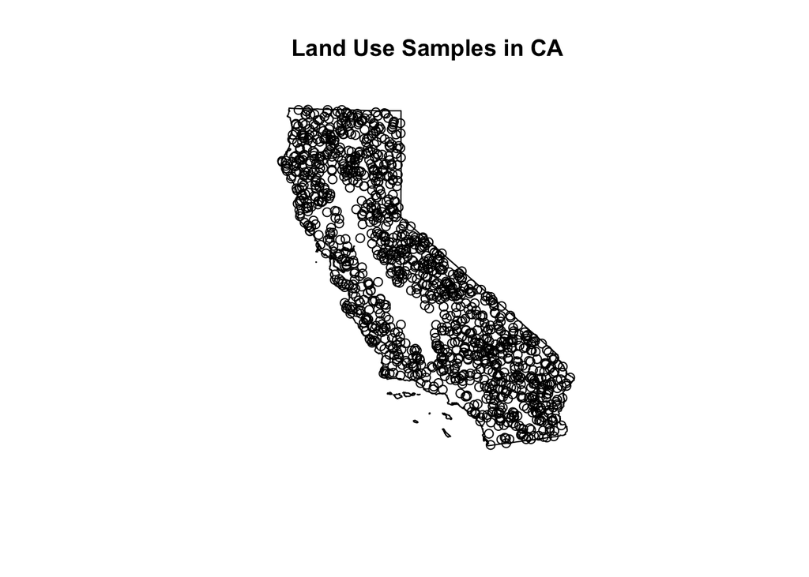

```r
#get usa borders
usa <- getData('GADM', country='USA', level=1)

#subset California
ca <- usa[usa$NAME_1 == 'California', ]

#specify a projection
teale_albers <- CRS('+proj=aea +lat_1=34 +lat_2=40.5 +lat_0=0 +lon_0=-120 +x_0=0 +y_0=-4000000 +datum=NAD83 +units=m')

#transform the subset into teale_albers
ca <- spTransform(ca, teale_albers)

#plot
plot(ca, main = "Land Use Samples in CA")
points(s)
```

```r
#we get a warning, why?
```

We did not collect climate data. But we have the locations of our samples, so we can extract that from other data sources. In this case we’ll use the the file ‘climate.grd’ (extracted from the WorldClim database). This file has multiple layers. In that case we can use the ‘brick’ function to create a multi-layered RasterBrick object.

```r
#load in the .grd into a RasterBrick
b <- brick(file.path(mypath, 'climate.grd'))
b
```

```
## class       : RasterBrick
## dimensions  : 1270, 1321, 1677670, 2  (nrow, ncol, ncell, nlayers)
## resolution  : 900, 900  (x, y)
## extent      : -636270, 552630, -612690, 530310  (xmin, xmax, ymin, ymax)
## coord. ref. : +proj=aea +lat_1=34 +lat_2=40.5 +lat_0=0 +lon_0=-120 +x_0=0 +y_0=-4000000 +datum=NAD83 +units=m +no_defs +ellps=GRS80 +towgs84=0,0,0
## data source : /Users/tyler/Dropbox/_200CN/labs/week4/data/climate.grd
## names       : temperature, precipitation
## min values  :   -5.450492,     37.615426
## max values  :      23.900,      2212.701
```

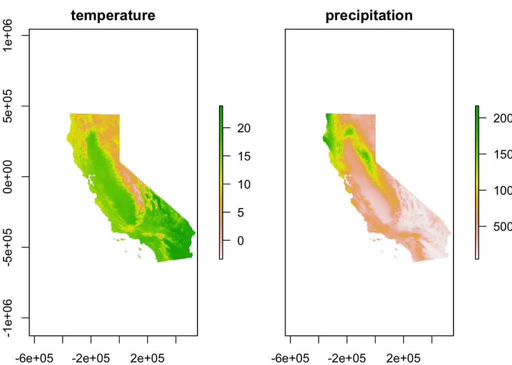

```r
plot(b)
```

## 6 Extract Raster

**Use the ‘extract’ function to extract raster cell values for each point**

```r
#extract, the y term must be in x, y format, so we exclude the third var in s
e <- raster::extract(b, s[,-3])

#bind the colums back (sort of like a join)
s <- cbind(s, e)

#check it out
head(s)
```

```
##         x       y     whr temperature precipitation
## 1  347880 -443940  Desert   14.035021      365.6130
## 2   61680    7860 Conifer    2.650328      619.3005
## 3 -137220 -187440   Shrub   11.582366      736.1567
## 4  503580 -455640  Desert   21.955955      107.1574
## 5 -255120  206760 Conifer    6.795314     1435.0140
## 6  298380 -502440   Shrub   13.947427      515.5257
```

Set 20% of the data apart to test the model.

```r
#ensure consistent randomness
set.seed(0)

#get random number of rows
i <- sample(nrow(s), 0.2 * nrow(s))

#subset into two different data sets
test <- s[i,]
train <- s[-i,]
```

## 7 Check that we have 80%

```r
#if we divide the number of obs in train by the number in s, we should get 80%
round(nrow(train)/nrow(s)*100)
```

```
## [1] 80
```

> 80% of the original data is in the `train` object.

Now we have the data to fit a LDA

```r
#fit model lda
lda <- lda(whr ~ temperature + precipitation, data=train)
lda
```

```
## Call:
## lda(whr ~ temperature + precipitation, data = train)
##
## Prior probabilities of groups:
## Barren/Other      Conifer       Desert     Hardwood   Herbaceous
##   0.03252033   0.27337398   0.29776423   0.08231707   0.13516260
##        Shrub
##   0.17886179
##
## Group means:
##              temperature precipitation
## Barren/Other    8.265085      594.2668
## Conifer         8.547464      956.2446
## Desert         18.398225      143.6991
## Hardwood       13.233499      862.5000
## Herbaceous     15.084583      526.4344
## Shrub          10.747338      574.8596
##
## Coefficients of linear discriminants:
##                        LD1          LD2
## temperature    0.216185040 -0.209616109
## precipitation -0.002188569 -0.002677092
##
## Proportion of trace:
##    LD1    LD2
## 0.9444 0.0556
```

## 8 Make a confusion matrix

```r
#create predictions from the lda model
p <- predict(lda)

#create a table of actuals (train) vs predicted (p)
tab <- table(train$whr,p$class)

#looks good
tab
```

```
##
##                Barren/Other Conifer Desert Hardwood Herbaceous Shrub
##   Barren/Other            0      21     11        0          0     0
##   Conifer                 0     213      4        2          1    49
##   Desert                  0       0    279        0          3    11
##   Hardwood                0      30      4       11         28     8
##   Herbaceous              0      11     59        2         49    12
##   Shrub                   0      39     14        2         37    84
```

## 9 Training Accuracy

**Compute the fraction correctly classified**

```r
#we can get the mean
mean(train$whr == p$class)
```

```
## [1] 0.6463415
```

```r
#or do the sum of the diag / the sum of the table
sum(diag(tab)) / sum(tab)
```

```
## [1] 0.6463415
```

> The percent of correctly classified observations is 65%.

## 10 Testing Accuracy

**Now compute the fraction correctly classified for the model testing data. (I get 0.592)**

```r
#get new predictions from the OG model with the test observations
p.test <- predict(lda, test)

#make a new table with those data
tab.test <- table(test$whr,p.test$class)

#looks good
tab.test
```

```
##
##                Barren/Other Conifer Desert Hardwood Herbaceous Shrub
##   Barren/Other            0       6      3        0          0     2
##   Conifer                 0      53      0        1          1    11
##   Desert                  0       0     58        0          1     5
##   Hardwood                0      13      0        5          8     3
##   Herbaceous              0       4     17        0          8     4
##   Shrub                   0       5     12        1          3    21
```

```r
#get the % correct
mean(test$whr == p.test$class)
```

```
## [1] 0.5918367
```

> The percent of correctly classified observations is 59%.

## 11 Easy / Hard Predictions

**What class seems to be easy to predict well, and what class not?**

```r
#we can look at the diag and divide by the rowSums to get the accuracy for each type.
diag(tab.test) / rowSums(tab.test)
```

```
## Barren/Other      Conifer       Desert     Hardwood   Herbaceous
##    0.0000000    0.8030303    0.9062500    0.1724138    0.2424242
##        Shrub
##    0.5000000
```

> It looks like conifer and desert seem to be easy to predict, while the remaning are difficult. Especially hardwood, herbaceous, and barren.

## 12. Why might that be?

> Perhaps it’s hard to tell in the data collection. The spectral signatures for confier and desert could be more distinct than that of hardwood, herbaceous, and desert. In addition, the desert is probably easiest to predict because of the percipitation data, as deserts don’t get a lot of rain, being deserts and all.

Now predict to all of California. We use the predict function from the ‘raster’ package. Note that in this case the first argument is not the fitted model, but a Raster* object that has values for the predictors used to fit the model.

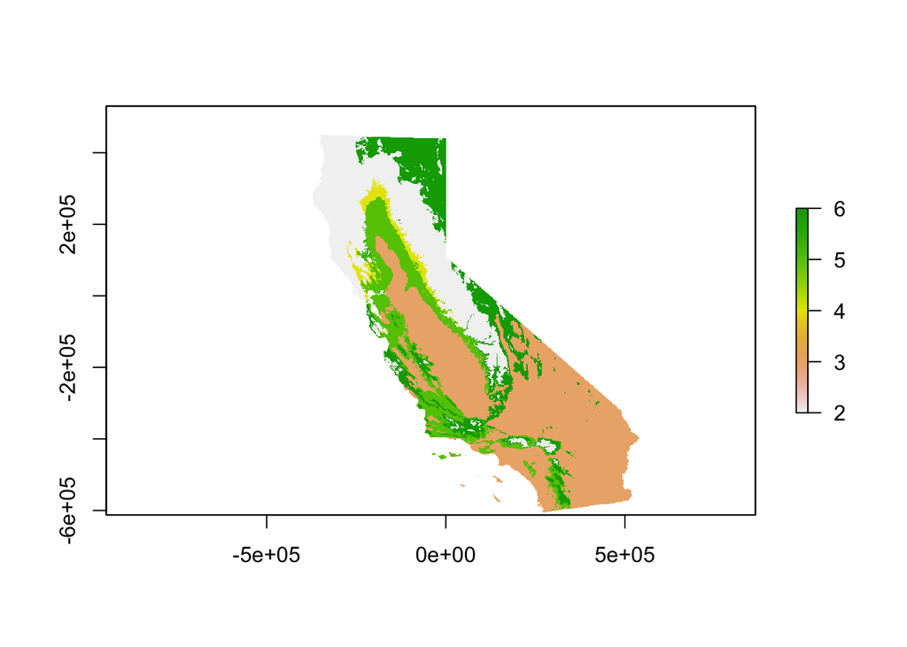

```r
pr <- predict(b, lda) # takes a little while
plot(pr)
```

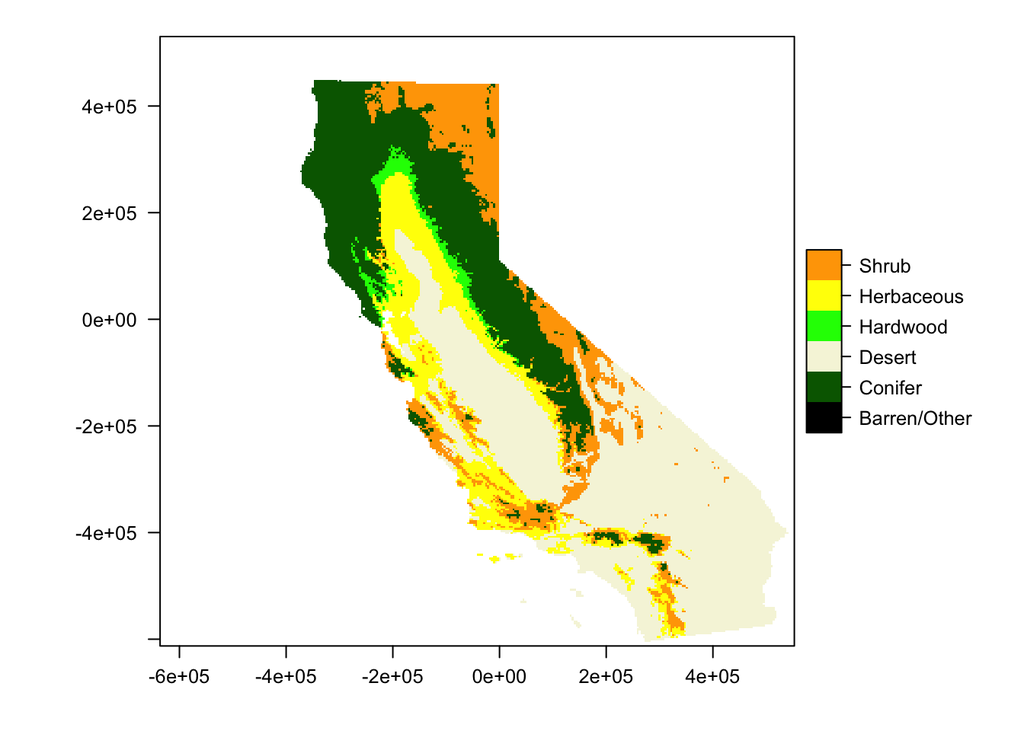

```r
#get levels from the lda data
levs <- data.frame(ID=1:length(lda$lev), class=lda$lev)

#reassign to the pr data
levels(pr) <- levs

#colors
cols <- rev(c('orange', 'yellow', 'green', 'beige', 'dark green', 'black'))

#map with color regions
levelplot(pr, col.regions = cols)
```

```r
#get veg grid data into raster
v <- raster(file.path(mypath, 'calveg.grd'))

#merge to get the levels in order
m <- merge(levels(v)[[1]], levels(pr)[[1]], by.x='WHR10NAME', by.y='class', all.x=TRUE)

#reclass the levels from v with the levels from the merge
v2 <- reclassify(v, m[,2:3])

#assign the levels from pr so everything matches
levels(v2) <- levels(pr)
```

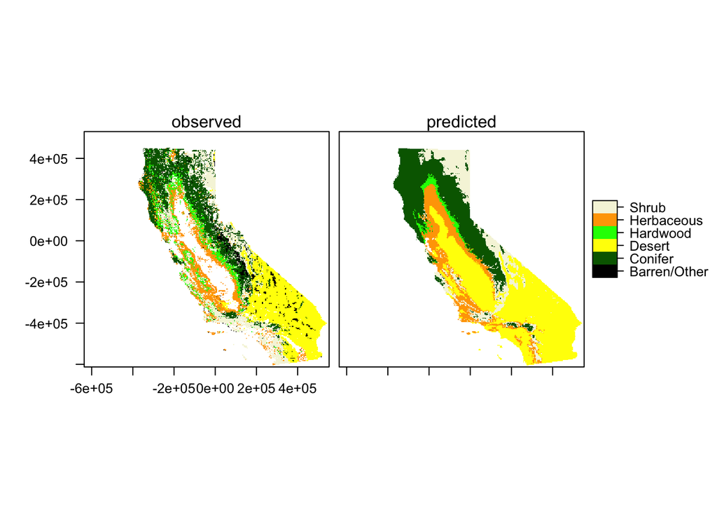

```r
#create a stack with the actual data and predicted
s <- stack(v2, pr)

#name them
names(s) <- c('observed', 'predicted')

#colors and plot
cols <- rev(c('beige', 'orange', 'green', 'yellow', 'dark green', 'black'))
levelplot(s, col.regions=cols)
```

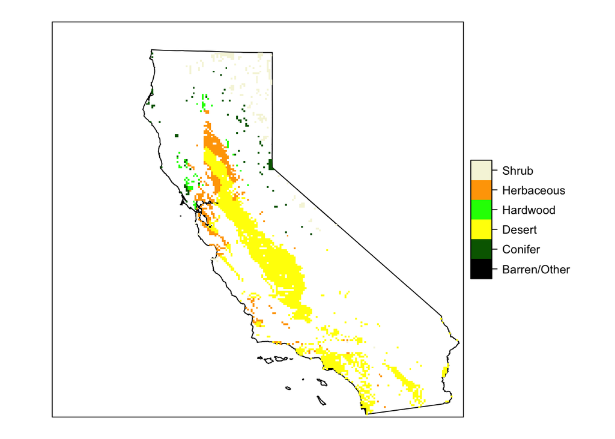

```r
#create a mask from the observed and the actual
x <- mask(pr, v2, inverse=TRUE)

#fix levels
levels(x) <- levels(pr)

#get the state bnd
state <- list("sp.polygons", ca)

#plot
spplot(x, col.regions=cols, sp.layout=state)
```

## 13 Undisturbed vs. Actual

**Compare the “undisturbed” vegetation to the actual vegetation. What vegetation type has seen most conversion to agriculture and urban areas (see code below)?**

```r
#get the freqencys from x
f <- freq(x, useNA='no')

#show me the levels!
merge(levels(x), f, by=1)
```

```
##   ID      class count
## 1  2    Conifer  3401
## 2  3     Desert 62920
## 3  4   Hardwood  1894
## 4  5 Herbaceous 14985
## 5  6      Shrub  6669
```

> Looks like desert has the largest number of predicted cells that have been converted to agriculture and urban areas.

## 14 Test by chance?

**How would you (conceptually or via R) test whether this is different from what could be expected by chance?**

> Create many random raster distributions using the same classes and compare it to the observed distribution of classes.